# Study on (tailcut) cleaning optimisation

Notes:

- This benchmark might not be optimal
- DL1 file prepared with ctapipe-stage1

The idea here is to define a benchmark to optimise cleaning independently of any reconstruction that would come **after**.  
This to avoid optimising the cleaning as a function of the whole reconstruction as:

- it can be tedious (you have to loop over the whole reconstruction)
- optimising cleaning before optimising the later part of the reconstruction might end up in reaching a cleaning well adapted to the reconstruction method chosen a priori but not good in absolute. (then a different/better reconstruction might end-up showing worst results)

This benchmark uses the the ground thruth image in photo-electron from MC simulations by computing the distance between the cleaned image and the ground truth as a function of cleaning method/parameters and finding the minimum of this distance (average on many events).

This also allow to study the cleaning as a function of event info (such as energy, signal amplitude... )

Of course, this supposes that the calibration has been previously optimised.

```python
from IPython.core.display import display, HTML
display(HTML("<style>.container { width:90% !important; }</style>"))
```

```python
import ctapipe
print(ctapipe.__version__)
```

```
0.10.5
```

```python
from ctapipe.io import EventSource
from ctapipe.utils import datasets
from ctapipe.calib import CameraCalibrator
from ctapipe.image import tailcuts_clean, dilate
from ctapipe.visualization import CameraDisplay
from ctapipe.instrument import CameraGeometry
import matplotlib.pyplot as plt
import numpy as np
from tqdm import tqdm
from scipy.stats import poisson
import os
from ctapipe.utils import get_dataset_path
from ctapipe.io import read_table
from ctapipe.instrument import SubarrayDescription  # for working with CTA instruments
from astropy.table import join

from ctapipe.utils.download import download_file_cached

import copy
import astropy.units as u
import tables
from astropy.table import Table, vstack
%matplotlib inline
```

```python
ls ../../prepared_data/
```

```
ls: cannot access '../../prepared_data/': No such file or directory
```

```python
remote_url = "http://cccta-dataserver.in2p3.fr/data/Prod5_Paranal_North_20deg_ctapipe_v0.10.5_DL1/"
filename = "gamma_20deg_0deg_run107___cta-prod5-paranal_desert-2147m-Paranal-dark_cone10_merged.DL1.h5"
```

```python
filename = download_file_cached(filename, default_url=remote_url)
```

```python
filename
```

```
PosixPath('/home/runner/.cache/ctapipe/cccta-dataserver.in2p3.fr/data/Prod5_Paranal_North_20deg_ctapipe_v0.10.5_DL1/gamma_20deg_0deg_run107___cta-prod5-paranal_desert-2147m-Paranal-dark_cone10_merged.DL1.h5')
```

```
Subarray : MonteCarloArray
Num Tels : 180
Footprint: 4.92 km2

       Type       Count     Tel IDs
----------------- ----- ---------------
 MST_MST_FlashCam    28 5-29,125-127
   LST_LST_LSTCam     4 1-4
   SST_ASTRI_CHEC   120 30-99,131-180
MST_MST_NectarCam    28 100-124,128-130
```

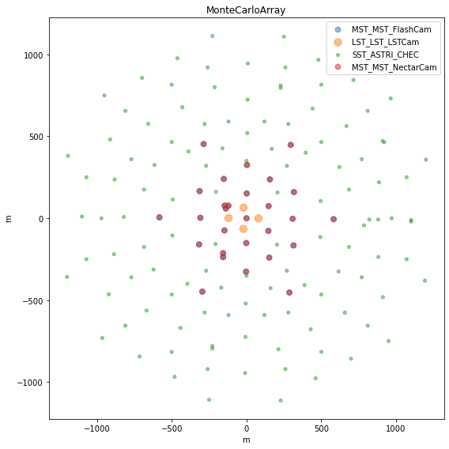

```python
subarray = SubarrayDescription.from_hdf(filename)
subarray.info()
subarray.peek()
```

```python
subarray.tel_ids
```

```
array([  1,   2,   3,   4,   5,   6,   7,   8,   9,  10,  11,  12,  13,
        14,  15,  16,  17,  18,  19,  20,  21,  22,  23,  24,  25,  26,
        27,  28,  29,  30,  31,  32,  33,  34,  35,  36,  37,  38,  39,
        40,  41,  42,  43,  44,  45,  46,  47,  48,  49,  50,  51,  52,
        53,  54,  55,  56,  57,  58,  59,  60,  61,  62,  63,  64,  65,
        66,  67,  68,  69,  70,  71,  72,  73,  74,  75,  76,  77,  78,
        79,  80,  81,  82,  83,  84,  85,  86,  87,  88,  89,  90,  91,
        92,  93,  94,  95,  96,  97,  98,  99, 100, 101, 102, 103, 104,
       105, 106, 107, 108, 109, 110, 111, 112, 113, 114, 115, 116, 117,
       118, 119, 120, 121, 122, 123, 124, 125, 126, 127, 128, 129, 130,
       131, 132, 133, 134, 135, 136, 137, 138, 139, 140, 141, 142, 143,
       144, 145, 146, 147, 148, 149, 150, 151, 152, 153, 154, 155, 156,
       157, 158, 159, 160, 161, 162, 163, 164, 165, 166, 167, 168, 169,
       170, 171, 172, 173, 174, 175, 176, 177, 178, 179, 180], dtype=int16)
```

```python
telescope_types = subarray.telescope_types
```

```python
def read_images_from_telescope_type(filename, telescope_type):
    images_tables = []
    for tel_id in subarray.get_tel_ids_for_type(telescope_type):
        images = read_table(filename, f"/dl1/event/telescope/images/tel_{tel_id:03d}")
        sim_images = read_table(filename, f"/simulation/event/telescope/images/tel_{tel_id:03d}")
        images_tables.append(join(images, sim_images, keys=['event_id', 'tel_id', 'obs_id']))

    return vstack(images_tables)
```

```python
subarray.to_table()
```

*Table length=180*

| tel_id int16 | pos_x m float64 | pos_y m float64 | pos_z m float64 | name str5 | type str3 | num_mirrors int64 | camera_type str9 | tel_description str17 |
| --- | --- | --- | --- | --- | --- | --- | --- | --- |
| 1 | -20.64299964904785 | -64.81700134277344 | 34.29999923706055 | LST | LST | 1 | LSTCam | LST_LST_LSTCam |
| 2 | 79.9939956665039 | -0.7680000066757202 | 29.399999618530273 | LST | LST | 1 | LSTCam | LST_LST_LSTCam |
| 3 | -19.395999908447266 | 65.19999694824219 | 31.0 | LST | LST | 1 | LSTCam | LST_LST_LSTCam |
| 4 | -120.03299713134766 | 1.1510000228881836 | 33.099998474121094 | LST | LST | 1 | LSTCam | LST_LST_LSTCam |
| 5 | -0.017000000923871994 | -0.0010000000474974513 | 24.350000381469727 | MST | MST | 1 | FlashCam | MST_MST_FlashCam |
| 6 | -1.468000054359436 | -151.2209930419922 | 31.0 | MST | MST | 1 | FlashCam | MST_MST_FlashCam |
| 7 | -3.1379997730255127 | -325.2449951171875 | 39.0 | MST | MST | 1 | FlashCam | MST_MST_FlashCam |
| 8 | 1.4339998960494995 | 151.22000122070312 | 25.0 | MST | MST | 1 | FlashCam | MST_MST_FlashCam |
| 9 | 3.1039998531341553 | 325.2430114746094 | 23.5 | MST | MST | 1 | FlashCam | MST_MST_FlashCam |
| ... | ... | ... | ... | ... | ... | ... | ... | ... |
| 171 | 260.0 | 920.0 | 45.0 | ASTRI | SST | 2 | CHEC | SST_ASTRI_CHEC |
| 172 | 260.0 | -920.0 | 65.0 | ASTRI | SST | 2 | CHEC | SST_ASTRI_CHEC |
| 173 | -500.0 | 815.0 | 15.0 | ASTRI | SST | 2 | CHEC | SST_ASTRI_CHEC |
| 174 | -500.0 | -815.0 | 75.0 | ASTRI | SST | 2 | CHEC | SST_ASTRI_CHEC |
| 175 | 500.0 | 815.0 | 45.0 | ASTRI | SST | 2 | CHEC | SST_ASTRI_CHEC |
| 176 | 500.0 | -815.0 | 53.0 | ASTRI | SST | 2 | CHEC | SST_ASTRI_CHEC |
| 177 | -810.0 | 655.0 | 12.0 | ASTRI | SST | 2 | CHEC | SST_ASTRI_CHEC |
| 178 | -810.0 | -655.0 | 68.0 | ASTRI | SST | 2 | CHEC | SST_ASTRI_CHEC |
| 179 | 810.0 | 655.0 | 20.0 | ASTRI | SST | 2 | CHEC | SST_ASTRI_CHEC |
| 180 | 810.0 | -655.0 | 41.0 | ASTRI | SST | 2 | CHEC | SST_ASTRI_CHEC |

```python
telescope_types
```

```
[TelescopeDescription(type=MST, name=MST, optics=MST, camera=FlashCam),
 TelescopeDescription(type=LST, name=LST, optics=LST, camera=LSTCam),
 TelescopeDescription(type=SST, name=ASTRI, optics=ASTRI, camera=CHEC),
 TelescopeDescription(type=MST, name=MST, optics=MST, camera=NectarCam)]
```

```python
tel_type = telescope_types[0]

geometry = subarray.tels[subarray.get_tel_ids_for_type(tel_type)[0]].camera.geometry
image_table = read_images_from_telescope_type(filename, tel_type)
```

```python
def residuals_after_cleaning(cleaned_image, true_image):
    return (cleaned_image-true_image)
```

```python
import copy

def add_residuals_to_table(image_table):
    cleaned_images = copy.deepcopy(image_table['image'])
    cleaned_images[~image_table['image_mask']]=0
    image_table['residuals'] = residuals_after_cleaning(cleaned_images, image_table['true_image'])
    image_table['accuracy'] = np.linalg.norm(image_table['residuals'], axis=1)
```

```python
add_residuals_to_table(image_table)
image_table[:3]
```

*Table length=3*

| obs_id int32 | event_id int64 | tel_id int16 | image [1764] float32 | peak_time [1764] float32 | image_mask [1764] bool | true_image [1764] int32 | residuals [1764] float64 | accuracy float64 |
| --- | --- | --- | --- | --- | --- | --- | --- | --- |
| 860 | 21604 | 5 | -0.6 .. 0.6 | 85.24 .. 64.97 | False .. False | 0 .. 0 | 0.0 .. 0.0 | 57.00771538250507 |
| 860 | 21609 | 5 | 3.2 .. -0.7 | 53.77 .. 54.86 | False .. False | 0 .. 0 | 0.0 .. 0.0 | 50.943988823544494 |
| 860 | 28506 | 5 | 5.6 .. -5.7 | 65.41 .. 48.08 | False .. False | 0 .. 0 | 0.0 .. 0.0 | 12.671622882409407 |

```
residuals mean:  0.2250397098023214
```

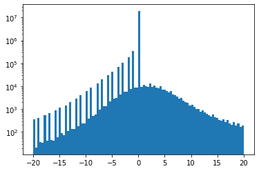

```python
plt.hist(image_table['residuals'].ravel(), log=True, bins=100, range=(-20, 20));
print("residuals mean: ", np.mean(np.abs(image_table['residuals'])))
```

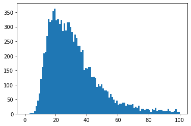

```python
plt.hist(image_table['accuracy'], bins=100, range=(0, 100));
```

```python
from matplotlib.colors import Normalize

def display_row(geometry, image_table, row_index=0):
    fig, axes = plt.subplots(1, 3, figsize=(20,5))
    row = image_table[row_index]

    display = CameraDisplay(geometry, row['image'], ax=axes[0])
    display.add_colorbar()
    display.highlight_pixels(row['image_mask'], color='red', alpha=0.3)
    display.axes.set_title('image')

    display = CameraDisplay(geometry, row['true_image'], ax=axes[1])
    display.add_colorbar()
    display.axes.set_title('true_image')

    if 'residuals' in row.colnames:
        display = CameraDisplay(geometry, row['residuals'], ax=axes[2], cmap='RdBu')
        max_pe = np.max(np.abs(row['residuals']))
        display.add_colorbar()
        display.set_limits_minmax(-max_pe, max_pe)
        display.axes.set_title('residuals')

    return axes
```

```python
image_table[4]
```

*Row index=4*

| obs_id int32 | event_id int64 | tel_id int16 | image [1764] float32 | peak_time [1764] float32 | image_mask [1764] bool | true_image [1764] int32 | residuals [1764] float64 | accuracy float64 |
| --- | --- | --- | --- | --- | --- | --- | --- | --- |
| 4447 | 77409 | 5 | -4.2 .. 1.4 | 20.07 .. 52.82 | False .. False | 0 .. 0 | 0.0 .. 0.0 | 15.574017021914528 |

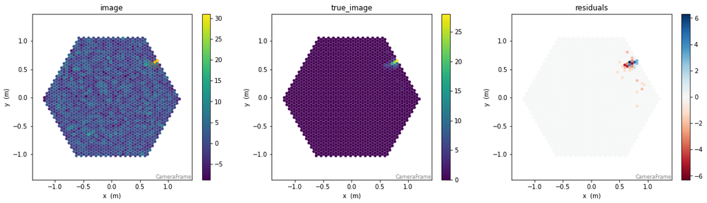

```python
display_row(geometry, image_table, 4);
```

## Find tailcut parameters that minimise residuals

```python
def thresholds_grid(image_table, pt_array=np.linspace(3, 12, 10)):
    acc = []
    picture_threshold = []
    boundary_threshold = []
    for pt in pt_array:
        for bt in np.linspace(0, pt, len(pt_array)):
            picture_threshold.append(pt)
            boundary_threshold.append(bt)
            tailcut_opt = dict(picture_thresh=pt, boundary_thresh=bt)
            image_mask = [tailcuts_clean(geometry, image, **tailcut_opt) for image in image_table['image']]
            image_table['image_mask'] = image_mask
            add_residuals_to_table(image_table)
#             acc.append(np.mean(image_table['accuracy']))
            acc.append((np.linalg.norm(image_table['residuals'].ravel(), ord=2))/image_table['residuals'].ravel().shape[0])

    return np.array(picture_threshold), np.array(boundary_threshold), np.array(acc)


def best_thresholds(picture_threshold, boundary_threshold, accuracy):
    """
    return picture_threshold, boundary_threshold
    """
    return picture_threshold[np.argmin(acc)], boundary_threshold[np.argmin(acc)]
```

```python
def plot_threshold_heatmap(picture_threshold, boundary_threshold, accuracy):
    fig, ax = plt.subplots(figsize=(10, 6))
    im = ax.tricontourf(picture_threshold,boundary_threshold,acc)
    cbar = plt.colorbar(im)
    ax.set_xlabel('picture threshold')
    ax.set_ylabel('boundary threhsold')
    cbar.set_label('accuracy')
    ax.axis('equal')
    return ax
```

```
---- MST_MST_FlashCam ----
Example:
```

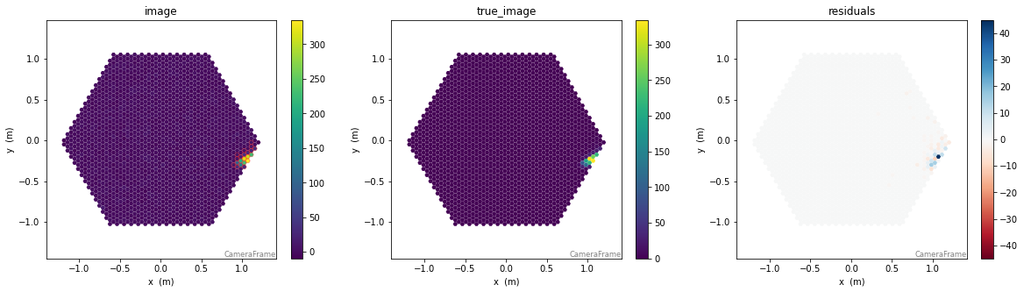

```
best threshold for MST_MST_FlashCam: (12.88888888888889, 2.864197530864198)
```

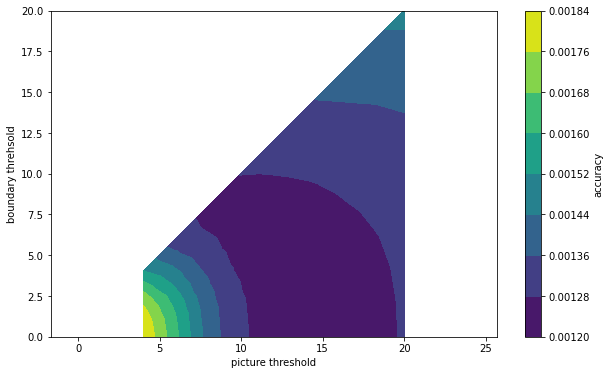

```
---- LST_LST_LSTCam ----
Example:
```

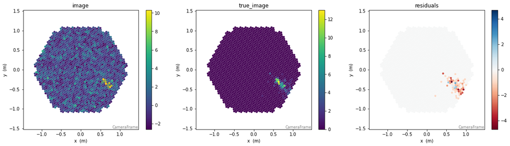

```
best threshold for LST_LST_LSTCam: (5.777777777777778, 1.9259259259259258)
```

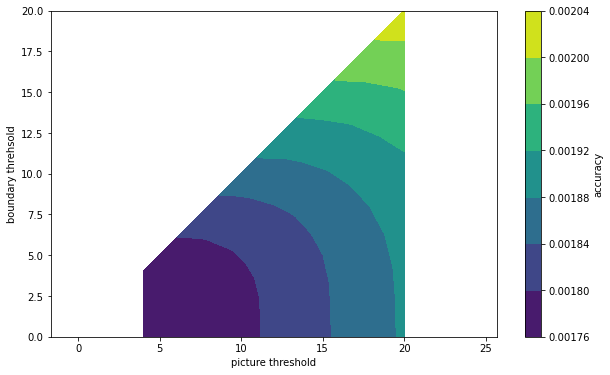

```
---- SST_ASTRI_CHEC ----
Example:
```

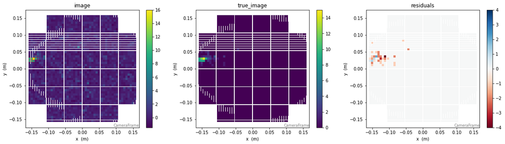

```
best threshold for SST_ASTRI_CHEC: (4.0, 0.0)
```

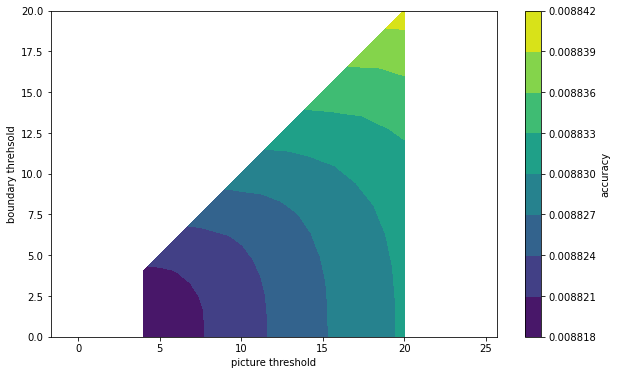

```
---- MST_MST_NectarCam ----
Example:
```

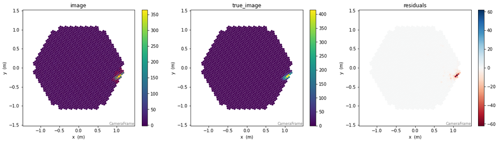

```
best threshold for MST_MST_NectarCam: (5.777777777777778, 0.0)
```

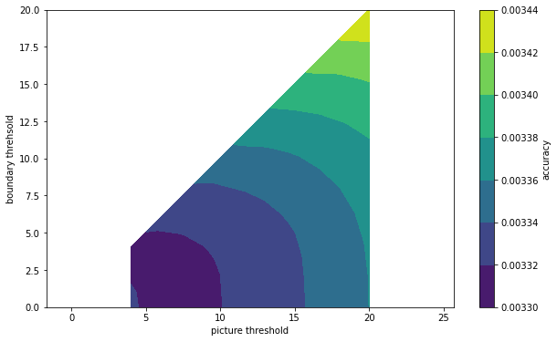

```python
for tel_type in telescope_types:
    print(f"---- {tel_type} ----")
    geometry = subarray.tels[subarray.get_tel_ids_for_type(tel_type)[0]].camera.geometry
    image_table = read_images_from_telescope_type(filename, tel_type)[:1000]
    add_residuals_to_table(image_table)
    print("Example:")
    display_row(geometry, image_table, 0)
    plt.show()

    pt, bt, acc = thresholds_grid(image_table, np.linspace(4, 20, 10))
    print(f"best threshold for {tel_type}: {best_thresholds(pt, bt, acc)}")
    plot_threshold_heatmap(pt, bt, acc)
    plt.show()
```